# Phase 2 - HackBio Data Contest

## Sample Size Distribution

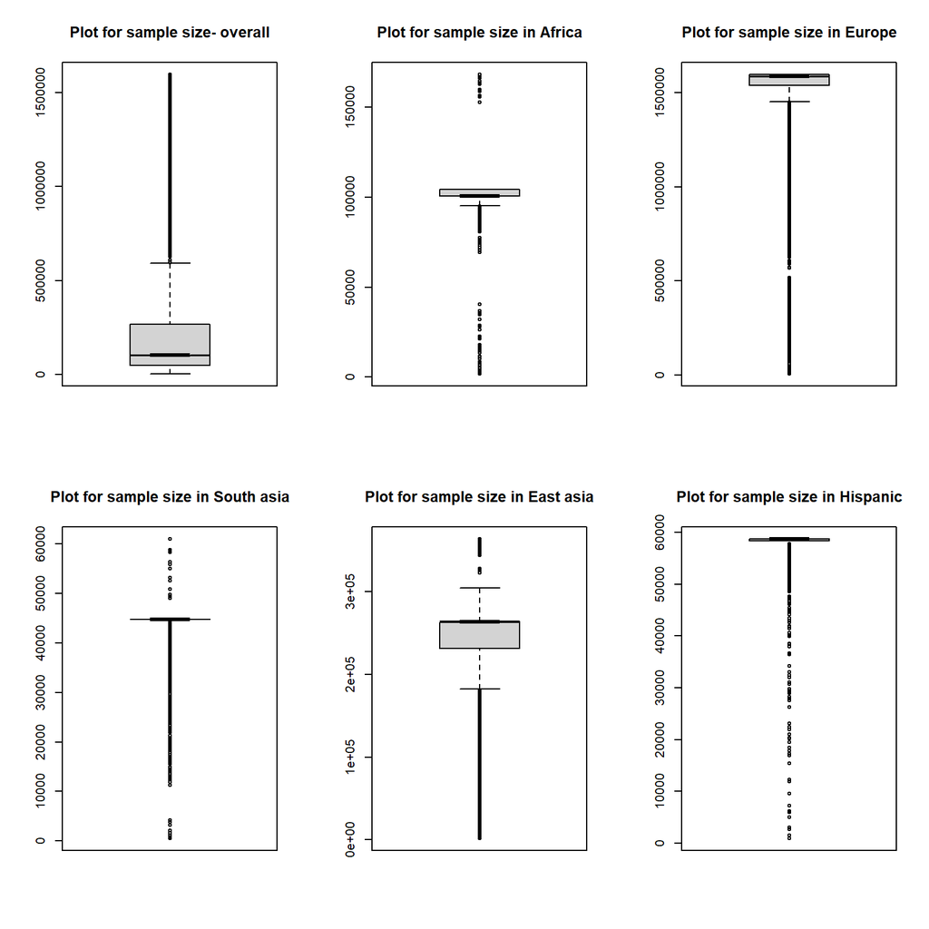

```r
# sample size distribution among different origins
par(mfrow = c (2,3))
boxplot(sample$N, notch = TRUE, main = "Plot for sample size- overall")
boxplot(african$N, notch = TRUE, main = "Plot for sample size in Africa")
boxplot(european$N, notch = TRUE, main = "Plot for sample size in Europe")
boxplot(south_asia$N, notch = TRUE, main = "Plot for sample size in South asia")
boxplot(east_asia$N, notch = TRUE, main = "Plot for sample size in East asia")
boxplot(hispanic$N,notch = TRUE, main = "Plot for sample size in Hispanic")
```

## Chromosome distribution in the raw data

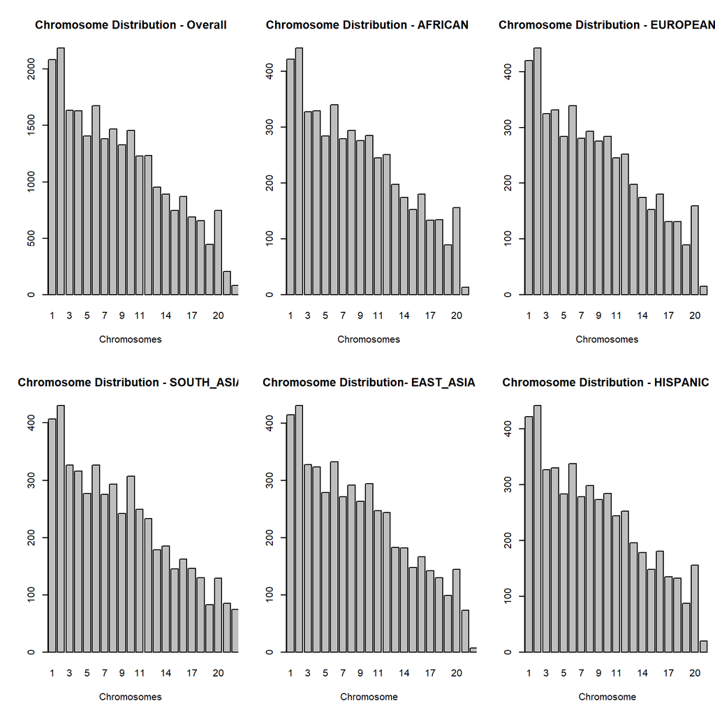

```r
#Chromosome distribution across different origins
par(mfrow = c (2,3))
barplot(table(sample$CHR), main = "Chromosome Distribution - Overall", xlab = "Chromosomes", xlim = c(1,22))
barplot(table(african$CHR), main = "Chromosome Distribution - AFRICAN ", xlab = "Chromosomes", xlim = c(1,22))
barplot(table(european$CHR), main = "Chromosome Distribution - EUROPEAN", xlab = "Chromosomes", xlim = c(1,22))
barplot(table(south_asia$CHR), main = "Chromosome Distribution - SOUTH_ASIA", xlab = "Chromosomes", xlim = c(1,22))
barplot(table(east_asia$CHR), main = "Chromosome Distribution- EAST_ASIA", xlab = "Chromosome", xlim = c(1,22))
barplot(table(hispanic$CHR), main = "Chromosome Distribution - HISPANIC ", xlab = "Chromosome", xlim = c(1,22))
```

## Position distribution

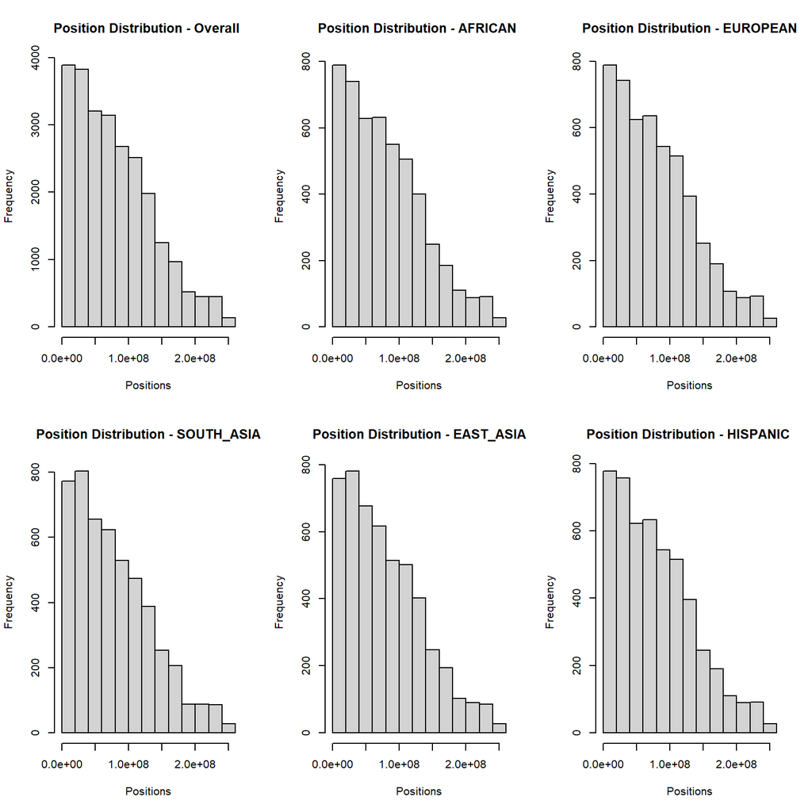

```r
# Position distribution across different origins
par(mfrow = c (2,3))
hist(sample$POS, main = "Position Distribution - Overall ", xlab = "Positions")
hist(african$POS, main = "Position Distribution - AFRICAN ", xlab = "Positions")
hist(european$POS, main = "Position Distribution - EUROPEAN", xlab = "Positions")
hist(south_asia$POS, main = "Position Distribution - SOUTH_ASIA", xlab = "Positions")
hist(east_asia$POS, main = "Position Distribution - EAST_ASIA", xlab = "Positions")
hist(hispanic$POS, main = "Position Distribution - HISPANIC ", xlab = "Positions")
```

### the below code results in the creation of dataframe containing MAFs value greater than 0.95, hence indicating that the following SNPs are highly responsible in Genetic Variation (more common and has been present in the population for a longer time).

```r
imp <- subset(significant_snps ,significant_snps$EFFECT_ALLELE_FREQ > 0.95 )
summary(imp)
```

```
##     SNPID               RSID                CHR              POS
##  Length:19          Length:19          Min.   : 1.000   Min.   :  3737495
##  Class :character   Class :character   1st Qu.: 2.000   1st Qu.: 40990906
##  Mode  :character   Mode  :character   Median : 5.000   Median : 64692041
##                                        Mean   : 7.211   Mean   : 92057998
##                                        3rd Qu.:12.000   3rd Qu.:135323988
##                                        Max.   :20.000   Max.   :227503125
##  EFFECT_ALLELE      OTHER_ALLELE       EFFECT_ALLELE_FREQ      BETA
##  Length:19          Length:19          Min.   :0.9510     Min.   :-0.39710
##  Class :character   Class :character   1st Qu.:0.9585     1st Qu.:-0.03348
##  Mode  :character   Mode  :character   Median :0.9650     Median : 0.00745
##                                        Mean   :0.9691     Mean   :-0.01870
##                                        3rd Qu.:0.9790     3rd Qu.: 0.02245
##                                        Max.   :1.0000     Max.   : 0.06510
##        SE                P                   N             ANCESTRY
##  Min.   :0.00255   Min.   :4.100e-08   Min.   :  58371   Length:19
##  1st Qu.:0.00321   1st Qu.:2.221e-03   1st Qu.: 104293   Class :character
##  Median :0.00983   Median :3.520e-03   Median : 262846   Mode  :character
##  Mean   :0.01638   Mean   :3.897e-03   Mean   : 595950
##  3rd Qu.:0.01475   3rd Qu.:6.866e-03   3rd Qu.:1451252
##  Max.   :0.13700   Max.   :8.413e-03   Max.   :1597370
```

```r
# a unique dataframe comtaining MAF values greater than 0.95
MAF_above_0.95 <- data.frame( Origin = imp$ANCESTRY,MAF = imp$EFFECT_ALLELE_FREQ, imp = imp$SNPID , RSID = imp$RSID, BETA = imp$BETA, sample_size = imp$N )
```

### Credits goes to HackBio for the datasets and organizing the data contest

### Citation: Yengo, L., Vedantam, S., Marouli, E. et al. A saturated map of common genetic variants associated with human height. Nature 610, 704–712 (2022). https://doi.org/10.1038/s41586-022-05275-y

### Thank you HackBio for the opportunity